# Sanità digitale sicura e sostenibile

[figure not shown]

[figure not shown]

[figure not shown]

[figure not shown]

Sanità digitale sicura e sostenibile

Le domande viaggiano, i dati restano.

Corrado Lanera

Università di Padova, Unità di Biostatistica, Epidemiologia e Sanità Pubblica

Istituto di Ricerca Pediatrica Città della Speranza

Digital Security Festival 2026, Padova, 4 novembre 2026

Testi, immagini e slide preparati con il supporto di strumenti di intelligenza artificiale generativa. Contenuti, scelte e verifiche sono dell’autore.

## Quando i vostri dati entrano in una ricerca, dove vanno?

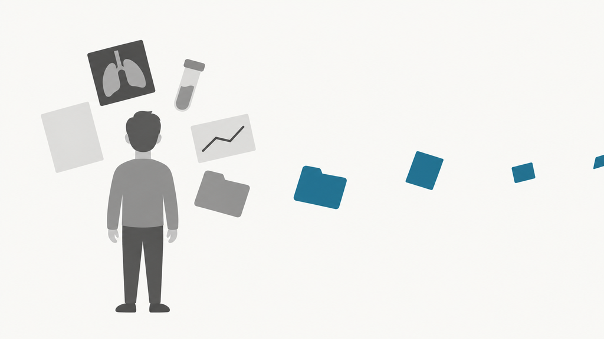

## Studi su più centri: l’approccio centralizzato sposta i dati

## Studi su più centri: l’approccio federato sposta l’analisi

[figure not shown]

## Analisi federata

federated analysis

**Che cos’è.** Un’analisi statistica su dati che restano in più centri: ogni centro esegue lo stesso calcolo sui propri dati e restituisce solo risultati aggregati, che chi analizza combina.

## Calcoli nei centri, risultato globale

analisi federata · come funziona

[figure not shown]

## Controlli e formato comune in ogni centro

analisi federata · come funziona

[figure not shown]

## Chi controlla l’accesso ai dati

analisi federata · che cosa cambia

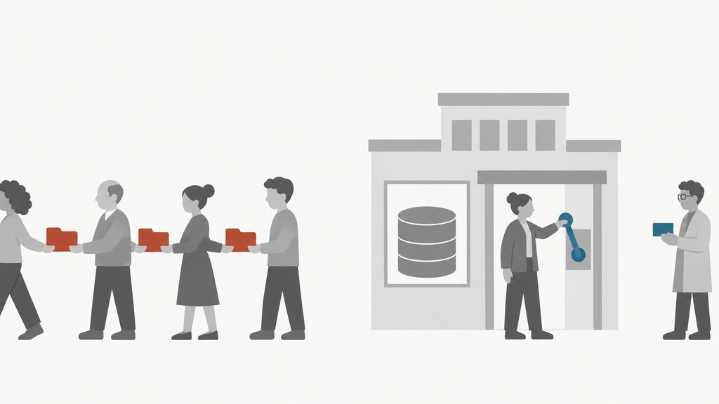

**copia dei dati**: passa di mano in mano, non si ritira

**analisi federata**: il centro concede e revoca le interrogazioni; escono solo risultati

## Limiti dell’analisi federata

analisi federata · limiti

**Domande combinate**  
31 pazienti in tutto, 30 sotto gli 80 anni: la differenza è una persona

**Pseudonimizzati, non anonimi**  
un codice al posto del nome; con la chiave o altre fonti si risale alla persona

**Errori che non si vedono**  
una protezione spenta per sbaglio, mentre il sistema risponde come sempre

**Casi rari**  
pochi pazienti per centro: le protezioni bloccano le risposte

## Apprendimento federato

federated learning

**Che cos’è.** Un modello di apprendimento automatico (machine learning) allenato su dati che restano in più centri: il coordinatore manda a tutti lo stesso modello, ogni centro lo allena sui propri dati e rimanda solo i suoi aggiornamenti, non i dati.

## Allenamento nei centri, aggiornamenti al coordinatore

apprendimento federato · come funziona

[figure not shown]

## Analisi federata e apprendimento federato a confronto

analisi e apprendimento federati · che cosa cambia, limiti

[figure not shown]

## Biobanca digitale e dati sintetici

digital biobank, synthetic data

**Biobanca:** conserva campioni biologici (sangue, tessuti, DNA) con le informazioni che li descrivono (tipo, data di raccolta, consenso) e li mette a disposizione della ricerca con regole di accesso. **Biobanca digitale:** lo stesso, con campioni digitali al posto di quelli biologici (cartelle cliniche, esami, immagini); qui, dati sintetici.

**Dati sintetici:** dati artificiali generati da un modello che ha imparato le proprietà statistiche di dati reali (per esempio come si legano età, diagnosi ed esiti); non sono i dati di pazienti reali.

## Generazione e verifica dei dati sintetici

dati sintetici · come funziona

[figure not shown]

## A che cosa servono i dati sintetici

dati sintetici · che cosa cambia, limiti

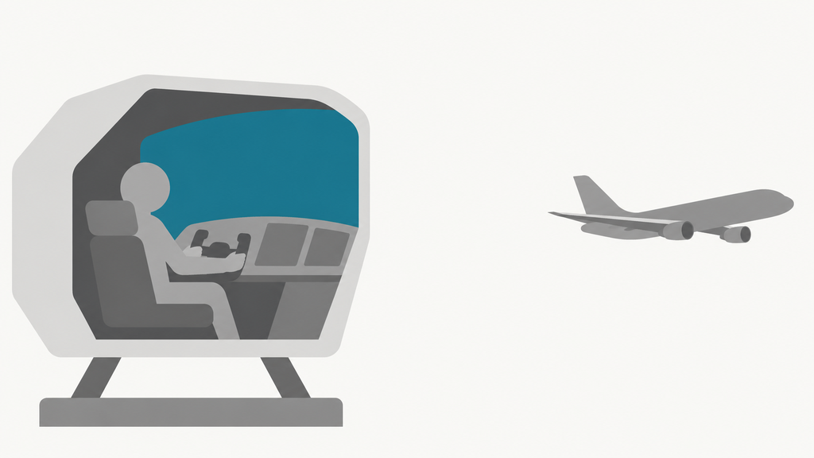

**dati sintetici**: provare i metodi

**dati veri**: domande cliniche

## Che cosa cambia

Quando i vostri dati entrano in una ricerca, dove vanno?

Ricerca fra più centri

ogni centro tiene i suoi dati

Uso dei dati sanitari

il centro concede le interrogazioni e può revocarle

Formato comune

ogni centro porta i suoi dati nello standard, chi li conosce meglio

I dati possono restare presso chi li custodisce.

Per approfondire o collaborare:

Corrado Lanera

Tenure-Track Assistant Professor, UBEP, DCTV, UniPD

Corrado.Lanera@ubep.unipd.it · @CorradoLanera

Prof. Dario Gregori

Head of UBEP, DCTV, UniPD · Dario.Gregori@ubep.unipd.it

PI, BIOSTAT-X, IRP Città della Speranza · biostat-x@ubep.unipd.it

Davide Ederle

Head of Innovation, IRP Città della Speranza ETS · innovation@irpcds.org

bit.ly/sanita-digitale-2026

[figure not shown]

[figure not shown]

[figure not shown]

Grazie per l’attenzione

## Referenze

**Analisi federata**

Gaye A et al. DataSHIELD: taking the analysis to the data, not the data to the analysis. *Int J Epidemiol* 2014;43(6):1929-44. doi:10.1093/ije/dyu188

Avraam D et al. DataSHIELD: mitigating disclosure risk in a multi-site federated analysis platform. *Bioinform Adv* 2025;5(1):vbaf046. doi:10.1093/bioadv/vbaf046

Dwork C et al. Exposed! A survey of attacks on private data. *Annu Rev Stat Appl* 2017;4:61-84. doi:10.1146/annurev-statistics-060116-054123

Rocher L, Hendrickx JM, de Montjoye YA. Estimating the success of re-identifications in incomplete datasets using generative models. *Nat Commun* 2019;10:3069. doi:10.1038/s41467-019-10933-3

Regolamento (UE) 2016/679 (GDPR), art. 4, punto 5, e considerando 26.

**Apprendimento federato**

McMahan HB et al. Communication-efficient learning of deep networks from decentralized data. *AISTATS* 2017, PMLR 54:1273-82.

Rieke N et al. The future of digital health with federated learning. *npj Digit Med* 2020;3:119. doi:10.1038/s41746-020-00323-1

Kairouz P et al. Advances and open problems in federated learning. *Found Trends Mach Learn* 2021;14(1-2):1-210. doi:10.1561/2200000083

Zhu L, Liu Z, Han S. Deep leakage from gradients. *NeurIPS* 2019.

Shokri R et al. Membership inference attacks against machine learning models. *IEEE S&P* 2017:3-18. doi:10.1109/SP.2017.41

Bonawitz K et al. Practical secure aggregation for privacy-preserving machine learning. *ACM CCS* 2017:1175-91. doi:10.1145/3133956.3133982

**Dati sintetici e biobanche**

Stadler T, Oprisanu B, Troncoso C. Synthetic data: anonymisation groundhog day. *USENIX Security* 2022:1451-68.

Jordon J et al. Synthetic data: what, why and how? Rapporto per la Royal Society, 2022. arXiv:2205.03257

Kaabachi B et al. A scoping review of privacy and utility metrics in medical synthetic data. *npj Digit Med* 2025;8:60. doi:10.1038/s41746-024-01359-3

Dwork C, Roth A. The algorithmic foundations of differential privacy. *Found Trends Theor Comput Sci* 2014;9(3-4):211-487. doi:10.1561/0400000042

OECD. Guidelines on human biobanks and genetic research databases. OECD, 2009.

**Strumenti e standard citati come esempi, non come raccomandazioni**

DataSHIELD (datashield.org) · Flower (flower.ai; Beutel DJ et al., arXiv:2007.14390) · OMOP Common Data Model v5.5 (ohdsi.github.io/CommonDataModel) · HL7 FHIR R5 (hl7.org/fhir)